# Tarea 1 - programación

-Marlon Gonzalo Briceño Cárdenas - Kresly Isabel Lavado Calderón - Anderson Alfonso Lliuya Carrera - 16/11/2021

# **PARTE 1**:

## *1.Calcula los valores numéricos aproximados de:*

### *a.*

```r
(0.3*0.15)/(0.3*0.15+0.2*0.8+0.5*0.12)
```

```
## [1] 0.1698113
```

### *b.*

```r
(5^6)*exp(-5)/factorial(6)
```

```
## [1] 0.1462228
```

### *c.*

```r
choose(20,7)*(0.4^7)*(0.6^13)
```

```
## [1] 0.1658823
```

## *2.Realizar la siguiente suma*

### *a.*

```r
sum(1:1000)
```

```
## [1] 500500
```

### *b.*

```r
Sumaexpo<-function(a,n){(1-a^(n+1))/(1-a)}
Sumaexpo(2,10)
```

```
## [1] 2047
```

## *3.El vector grupo representa el grupo al que pertenece una serie de alumnos*

### *a.¿Cuántos elementos tiene?*

```r
load(url("https://goo.gl/uDzU8v"))
grupo
```

```
##   [1] "B" "A" "E" "D" "B" "D" "D" "A" "D" "C" "D" "E" "B" "E" "E" "E" "A" "B"
##  [19] "C" "C" "A" "C" "C" "D" "D" "E" "E" "A" "B" "C" "C" "E" "D" "C" "E" "E"
##  [37] "E" "E" "D" "D" "D" "E" "E" "E" "D" "E" "B" "E" "D" "C" "E" "D" "E" "E"
##  [55] "C" "B" "D" "C" "E" "D" "E" "B" "D" "B" "B" "C" "D" "C" "C" "C" "E" "D"
##  [73] "E" "D" "C" "D" "E" "E" "C" "D" "C" "E" "D" "A" "B" "B" "E" "E" "C" "D"
##  [91] "C" "E" "E" "C" "E" "D" "D" "D" "E" "D" "A" "D" "B" "B" "C" "D" "E" "A"
## [109] "E" "E" "A" "C" "E" "D" "A" "D" "D" "C" "E" "E" "E" "D" "A" "E" "E" "E"
## [127] "C" "C" "B" "C" "C" "D" "C" "B" "C" "A" "D" "E" "D" "E" "E" "B" "E" "E"
## [145] "E" "E" "C" "B" "D" "D" "E" "E" "D" "D" "E" "D" "E" "D" "D" "C" "D" "D"
## [163] "D" "C" "E" "D" "E" "C" "E" "B" "C" "C" "C" "D" "D" "B" "D" "B" "E" "C"
## [181] "E" "D" "D" "E" "D" "B" "B" "E" "E" "A" "C" "A"
```

```r
length(grupo)
```

```
## [1] 192
```

```r
View(grupo)
```

### *b.¿En qué posiciones del vector está la letra “A”?*

```r
which(grupo == "A",)
```

```
##  [1]   2   8  17  21  28  84 101 108 111 115 123 136 190 192
```

## *4.El vector nota representa la nota de un examen de los alumnos que están en los grupos del vector grupo.*

### *a.¿Cuanto suman todas las notas?*

```r
sum(nota)
```

```
## [1] 962
```

### *b.¿Cual es la media aritmética de todas las notas?*

```r
mean(nota)
```

```
## [1] 5.010417
```

### *c.¿En qué posiciones están las notas mayores de 7.0?*

```r
which(nota>7)
```

```
## [1]  81 103 120 151
```

```r
nota
```

```
##   [1] 4.9 5.4 5.2 6.8 5.0 6.2 4.4 4.1 4.3 5.5 5.5 4.8 6.4 6.8 5.5 4.7 5.2 6.4
##  [19] 4.8 3.4 4.7 6.0 5.9 5.4 5.3 5.6 6.9 5.6 4.2 4.4 5.8 4.8 6.1 6.2 6.6 5.2
##  [37] 4.6 5.0 2.5 4.0 5.6 4.9 5.4 3.9 4.2 4.7 4.2 5.4 3.7 6.2 5.9 3.7 5.8 2.7
##  [55] 5.6 5.0 2.6 5.0 4.9 3.4 5.9 4.3 6.1 4.5 5.5 3.2 3.2 6.4 4.4 6.0 5.0 5.4
##  [73] 7.0 3.8 4.2 4.7 4.7 5.3 6.8 4.0 7.2 4.8 6.0 4.1 4.5 5.8 2.9 5.0 4.6 4.9
##  [91] 6.8 4.2 6.9 5.7 5.7 6.4 4.4 4.2 4.5 5.8 4.3 3.7 7.4 3.9 5.2 4.9 3.6 5.5
## [109] 6.0 5.0 4.1 4.5 3.1 5.4 4.5 5.3 4.7 6.1 5.2 7.7 5.3 5.0 4.0 5.2 4.0 5.5
## [127] 4.0 5.4 4.6 3.4 6.2 5.7 3.8 4.8 4.0 4.4 5.5 5.9 5.9 5.7 4.9 1.7 5.5 5.9
## [145] 5.5 3.8 5.5 6.0 3.5 5.5 7.5 3.4 5.8 4.7 3.6 4.1 5.0 4.6 3.6 4.7 4.1 5.7
## [163] 5.9 4.7 3.2 5.5 3.0 4.5 5.5 5.9 5.6 6.0 4.4 3.7 4.4 6.8 6.1 4.7 4.2 6.2
## [181] 5.2 5.1 2.9 6.5 4.2 5.4 5.9 6.2 6.3 4.8 5.6 2.9
```

```r
sort(nota,decreasing=TRUE)
```

```
##   [1] 7.7 7.5 7.4 7.2 7.0 6.9 6.9 6.8 6.8 6.8 6.8 6.8 6.6 6.5 6.4 6.4 6.4 6.4
##  [19] 6.3 6.2 6.2 6.2 6.2 6.2 6.2 6.1 6.1 6.1 6.1 6.0 6.0 6.0 6.0 6.0 6.0 5.9
##  [37] 5.9 5.9 5.9 5.9 5.9 5.9 5.9 5.9 5.8 5.8 5.8 5.8 5.8 5.7 5.7 5.7 5.7 5.7
##  [55] 5.6 5.6 5.6 5.6 5.6 5.6 5.5 5.5 5.5 5.5 5.5 5.5 5.5 5.5 5.5 5.5 5.5 5.5
##  [73] 5.5 5.4 5.4 5.4 5.4 5.4 5.4 5.4 5.4 5.3 5.3 5.3 5.3 5.2 5.2 5.2 5.2 5.2
##  [91] 5.2 5.2 5.1 5.0 5.0 5.0 5.0 5.0 5.0 5.0 5.0 5.0 4.9 4.9 4.9 4.9 4.9 4.9
## [109] 4.8 4.8 4.8 4.8 4.8 4.8 4.7 4.7 4.7 4.7 4.7 4.7 4.7 4.7 4.7 4.7 4.6 4.6
## [127] 4.6 4.6 4.5 4.5 4.5 4.5 4.5 4.5 4.4 4.4 4.4 4.4 4.4 4.4 4.4 4.3 4.3 4.3
## [145] 4.2 4.2 4.2 4.2 4.2 4.2 4.2 4.2 4.1 4.1 4.1 4.1 4.1 4.0 4.0 4.0 4.0 4.0
## [163] 4.0 3.9 3.9 3.8 3.8 3.8 3.7 3.7 3.7 3.7 3.6 3.6 3.6 3.5 3.4 3.4 3.4 3.4
## [181] 3.2 3.2 3.2 3.1 3.0 2.9 2.9 2.9 2.7 2.6 2.5 1.7
```

```r
which.max(nota)
```

```
## [1] 120
```

## *5.A partir de los vectores grupo y nota definidos.*

### *a.Suma las notas de los 10 primeros alumnos del vector*

```r
sum(nota[1:10])
```

```
## [1] 51.8
```

### *b.¿Cuántos alumnos hay del grupo C?*

```r
length(grupo[grupo=="C"])
```

```
## [1] 39
```

### *c.¿Cuántos alumnos han aprobado?*

```r
length(nota[nota>=5])
```

```
## [1] 102
```

### *d.¿Cuántos alumnos del grupo B han aprobado?*

```r
length(nota[grupo=="B" & nota>=5])
```

```
## [1] 12
```

### *e.¿Qué porcentaje de alumnos del grupo C han aprobado?*

```r
length(nota[grupo=="C" & nota>=5])/length(nota[grupo=="C"])*100
```

```
## [1] 58.97436
```

### *f.¿De qué grupos son la máxima y mínima notas de toda la muestra?*

```r
grupo[which.max(nota)]
```

```
## [1] "E"
```

```r
grupo[which.min(nota)]
```

```
## [1] "B"
```

### *g.Nota media de los alumnos de grupo A y B, juntos, considerando sólo a los que han aprobado.*

```r
mean(nota[(grupo=="B"| grupo=="A") & nota>=5])
```

```
## [1] 5.825
```

## **6.Calcula el percentil 66 de las notas de todos los alumnos, y también de los alumnos del grupo C.**

```r
sort(nota)
```

```
##   [1] 1.7 2.5 2.6 2.7 2.9 2.9 2.9 3.0 3.1 3.2 3.2 3.2 3.4 3.4 3.4 3.4 3.5 3.6
##  [19] 3.6 3.6 3.7 3.7 3.7 3.7 3.8 3.8 3.8 3.9 3.9 4.0 4.0 4.0 4.0 4.0 4.0 4.1
##  [37] 4.1 4.1 4.1 4.1 4.2 4.2 4.2 4.2 4.2 4.2 4.2 4.2 4.3 4.3 4.3 4.4 4.4 4.4
##  [55] 4.4 4.4 4.4 4.4 4.5 4.5 4.5 4.5 4.5 4.5 4.6 4.6 4.6 4.6 4.7 4.7 4.7 4.7
##  [73] 4.7 4.7 4.7 4.7 4.7 4.7 4.8 4.8 4.8 4.8 4.8 4.8 4.9 4.9 4.9 4.9 4.9 4.9
##  [91] 5.0 5.0 5.0 5.0 5.0 5.0 5.0 5.0 5.0 5.1 5.2 5.2 5.2 5.2 5.2 5.2 5.2 5.3
## [109] 5.3 5.3 5.3 5.4 5.4 5.4 5.4 5.4 5.4 5.4 5.4 5.5 5.5 5.5 5.5 5.5 5.5 5.5
## [127] 5.5 5.5 5.5 5.5 5.5 5.5 5.6 5.6 5.6 5.6 5.6 5.6 5.7 5.7 5.7 5.7 5.7 5.8
## [145] 5.8 5.8 5.8 5.8 5.9 5.9 5.9 5.9 5.9 5.9 5.9 5.9 5.9 6.0 6.0 6.0 6.0 6.0
## [163] 6.0 6.1 6.1 6.1 6.1 6.2 6.2 6.2 6.2 6.2 6.2 6.3 6.4 6.4 6.4 6.4 6.5 6.6
## [181] 6.8 6.8 6.8 6.8 6.8 6.9 6.9 7.0 7.2 7.4 7.5 7.7
```

```r
quantile(nota,66/100)
```

```
## 66%
## 5.5
```

```r
quantile(nota[grupo=="C"],66/100)
```

```
##   66%
## 5.808
```

## **7.Un alumno tiene una nota de 4.9. ¿Qué porcentaje, del total de alumnos, tiene una nota menor o igual que la suya? ¿Y qué porcentaje tiene una nota mayor o igual que la suya?**

```r
length(nota[nota<=4.9])/length(nota)*100
```

```
## [1] 46.875
```

```r
quantile(nota,46.875/100)
```

```
##  46.875%
## 4.953125
```

```r
length(nota[nota>=4.90])/length(nota)*100
```

```
## [1] 56.25
```

```r
quantile(nota,c(0/100,46.875/100,66/100,100/100))
```

```
##       0%  46.875%      66%     100%
## 1.700000 4.953125 5.500000 7.700000
```

## **8.Realiza el gráfico de diagramas de caja de las notas de cada grupo, para poder comparar el nivel de cada uno de ellos.**

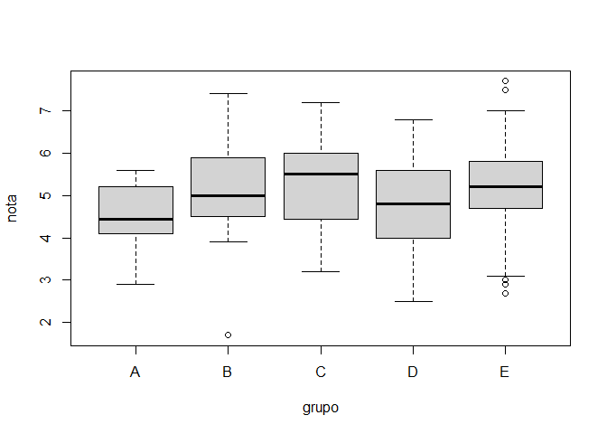

```r
boxplot(nota~grupo)
```

## **9.Si la variable conc recoge la concentración de plomo (en ppm) en el aire de cierta zona durante un día completo**

### *a.¿Cuál ha sido la concentración máxima?*

```r
conc[which.max(conc)]
```

```
## [1] 47.34
```

```r
which.max(conc)
```

```
## [1] 142
```

### *b.¿En cuántos de los muestreos se ha superado la concentración de 40.0 ppm?*

```r
length(conc[conc>=40.0])
```

```
## [1] 61
```

### *c.¿Cuál ha sido la concentración media del día?*

```r
mean(conc)
```

```
## [1] 24.07229
```

### *d.¿Cuáles fueron las 10 mediciones más bajas del día?*

```r
sort(conc)
```

```
##   [1]  0.93  1.07  1.77  2.03  2.58  2.73  2.75  2.88  2.88  2.91  2.96  3.05
##  [13]  3.10  3.11  3.15  3.37  3.46  3.54  3.55  3.57  3.67  3.75  3.75  3.80
##  [25]  3.86  3.87  4.00  4.14  4.36  4.60  4.76  5.21  5.48  5.48  5.50  5.66
##  [37]  5.69  5.70  5.79  5.96  6.13  6.14  6.14  6.15  6.19  6.48  6.48  6.88
##  [49]  6.88  6.92  6.94  6.96  7.07  7.11  7.14  7.24  7.32  7.66  7.77  7.80
##  [61]  8.27  8.38  8.67  8.68  8.85  8.96  9.06  9.17  9.28  9.42  9.51  9.83
##  [73]  9.99 10.31 10.54 10.57 10.61 10.65 10.73 11.09 11.20 11.28 11.65 11.67
##  [85] 11.71 11.72 12.24 12.48 12.48 12.56 12.64 12.91 13.14 13.87 14.03 14.10
##  [97] 14.10 14.69 14.78 14.86 14.98 15.09 15.46 15.51 15.58 15.83 16.22 16.53
## [109] 16.60 16.81 17.31 17.37 17.51 17.67 17.71 18.03 18.05 18.37 18.48 18.95
## [121] 19.00 19.36 19.40 19.48 19.75 19.81 20.20 20.37 20.63 20.93 21.81 21.91
## [133] 21.98 22.40 22.70 22.78 22.82 22.85 23.74 23.74 23.93 24.28 24.32 24.33
## [145] 24.51 24.59 24.71 24.81 24.84 25.06 25.21 25.27 25.57 25.62 25.65 25.67
## [157] 25.97 26.65 27.45 27.52 27.74 27.86 27.99 28.28 28.61 28.73 28.88 29.05
## [169] 29.32 30.03 30.50 30.55 30.63 30.93 30.97 31.06 31.24 31.36 31.56 31.72
## [181] 32.11 32.46 32.54 32.61 32.70 32.71 32.76 32.79 33.46 33.63 34.23 34.24
## [193] 34.54 34.83 35.08 35.19 35.48 35.51 35.97 36.01 36.11 36.19 36.34 36.50
## [205] 36.69 37.34 37.59 37.79 37.80 37.86 37.95 37.97 38.08 38.11 38.12 38.18
## [217] 38.18 38.66 38.67 38.89 39.05 39.10 39.12 39.15 39.36 39.43 39.54 40.08
## [229] 40.12 40.29 40.45 40.49 40.52 40.57 40.95 40.99 41.10 41.34 41.48 41.52
## [241] 41.67 41.73 41.81 41.90 41.97 42.05 42.06 42.19 42.23 42.26 42.29 42.30
## [253] 42.36 42.42 42.46 42.52 42.56 42.70 42.76 42.77 42.98 43.02 43.11 43.17
## [265] 43.18 43.38 43.66 43.71 43.72 43.77 43.84 43.86 43.88 44.04 44.49 44.64
## [277] 44.80 44.91 45.00 45.32 45.37 45.39 45.57 45.57 45.71 45.97 46.70 47.34
```

```r
sort(conc)[1:10]
```

```
##  [1] 0.93 1.07 1.77 2.03 2.58 2.73 2.75 2.88 2.88 2.91
```

### *e.Si la primera medida fue a las 00:00. ¿A qué hora del día se alcanzó la concentración máxima?*

```r
conc
```

```
##   [1]  4.76  4.60  6.14  2.96  3.15  1.77  4.36  4.00  2.03  6.13  2.88  6.15
##  [13]  3.05  3.37  5.21  3.10  3.57  7.11  7.32  2.75  6.96  7.66  3.54  6.48
##  [25]  6.19  7.77  8.96  6.94  5.70  7.14  8.38  5.69  7.24 10.57  9.99  9.83
##  [37]  9.06 11.28  7.07 11.09 11.20 10.73 12.24 13.14 14.69 12.48 12.91 12.48
##  [49] 14.10 13.87 14.98 15.46 17.67 14.78 17.51 14.10 16.60 19.75 14.86 20.63
##  [61] 18.37 19.81 19.40 19.48 19.36 21.91 22.70 24.81 23.74 21.98 22.40 24.28
##  [73] 25.27 25.67 23.74 24.33 24.51 26.65 25.65 27.74 29.32 29.05 31.06 28.73
##  [85] 30.97 31.36 28.61 30.50 31.72 30.93 32.61 32.76 31.24 34.54 32.11 34.23
##  [97] 35.08 36.34 32.54 35.51 36.19 35.97 37.79 36.69 38.18 36.11 38.08 39.05
## [109] 38.11 37.86 40.08 39.36 42.05 39.43 37.80 39.10 40.99 41.34 38.66 41.48
## [121] 43.77 42.70 42.42 42.30 43.72 40.57 40.49 41.81 43.84 45.71 42.26 45.00
## [133] 42.76 45.97 44.04 43.17 42.56 43.11 42.46 42.29 44.80 47.34 45.32 44.49
## [145] 45.57 46.70 43.86 45.39 43.38 43.02 43.66 44.64 45.57 43.71 42.77 43.88
## [157] 43.18 41.67 45.37 40.52 42.98 44.91 41.52 40.12 41.97 42.36 42.52 40.95
## [169] 39.12 42.23 41.90 41.73 42.19 41.10 40.45 38.89 37.95 42.06 37.97 40.29
## [181] 36.50 38.18 37.34 38.67 39.15 39.54 38.12 37.59 33.63 36.01 33.46 32.70
## [193] 35.48 35.19 34.83 32.79 30.55 34.24 31.56 27.99 30.63 32.71 28.28 30.03
## [205] 32.46 27.45 28.88 25.21 27.86 25.62 24.71 25.06 27.52 24.32 25.57 24.59
## [217] 25.97 22.82 24.84 20.93 23.93 22.78 20.20 22.85 21.81 17.71 18.03 18.05
## [229] 18.95 17.31 15.58 16.22 15.83 18.48 16.81 19.00 17.37 20.37 16.53 14.03
## [241] 15.51 11.71 11.72 10.65 15.09 12.64 12.56 11.65  8.68 10.61 10.54  6.88
## [253]  8.85  6.92 11.67 10.31  9.51  8.27  9.42  9.28  8.67  6.48  6.14  5.48
## [265]  4.14  5.50  9.17  3.86  3.80  5.66  2.73  7.80  3.75  5.96  3.75  6.88
## [277]  5.79  2.91  2.88  2.58  3.11  0.93  1.07  3.46  3.87  5.48  3.67  3.55
```

```r
length(conc)
```

```
## [1] 288
```

- Minutos totales

```r
((which.max(conc)-1)*60*24)/length(conc)
```

```
## [1] 705
```

- Horas totales

```r
((which.max(conc)-1)*24)/length(conc)
```

```
## [1] 11.75
```

- Minutos sobrantes

```r
(((which.max(conc)-1)*24)/length(conc)-11)*60
```

```
## [1] 45
```

- Horas

```r
((which.max(conc)-1)*24)/length(conc)-0.75
```

```
## [1] 11
```

- Hora del día
  - Rpta:(11:45 am)

# **Parte2**

## *Graficar los puntos en un plano utilizando RStudio.*

### *1.Graficar los puntos (1,1), (2,4), (3,9), (4,16), (5,25), (6,36), (7,49), (8,64), (9,81), (10,100)en un plano utilizando RStudio.*

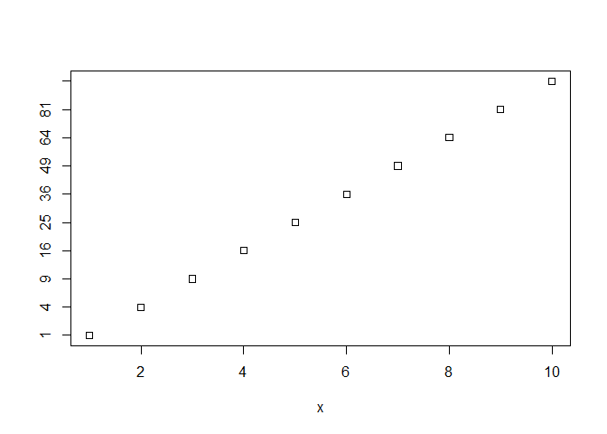

```r
x <- c(1,2,3,4,5,6,7,8,9,10)
y <- c(1,4,9,16,25,36,49,64,81,100)
stripchart(x~y)
```

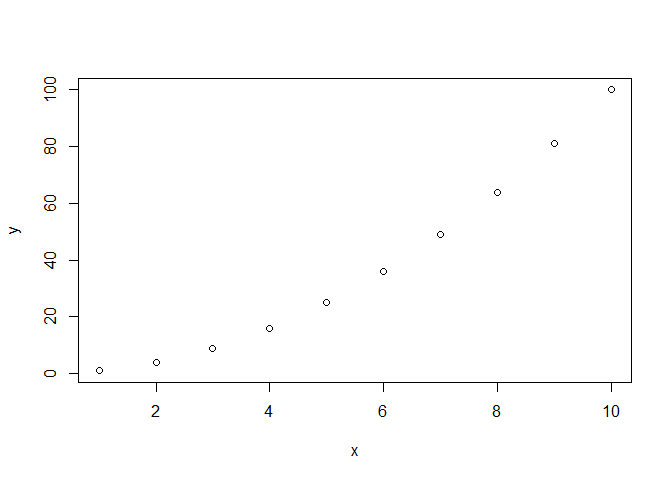

```r
plot(x,y)
```

### *2.Ingresar la matriz A en RStudio*

```r
a <-c(1,2,3,4)
b <-c(2,4,6,8)
c <-c(3,6,9,12)
matrix(c(a,b,c),nrow = 4,ncol = 3)
```

```
##      [,1] [,2] [,3]
## [1,]    1    2    3
## [2,]    2    4    6
## [3,]    3    6    9
## [4,]    4    8   12
```

```r
z <- c(1,2,3,4,2,4,6,8,3,6,9,12)
A=matrix(z,nrow = 4, ncol = 3)
```

### *3.Ingresar la matriz identidad de tamaño 3*

```r
I=matrix(c(1,0,0,0,1,0,0,0,1),nrow = 3,ncol = 3)
```

### *4.Crea una funciÃ³n que cree una matriz nula ingresando las dimensiones*

```r
matriznula<-function(x,y){matrix(c(0),nrow = y,ncol = x)}
matriznula(6,7)
```

```
##      [,1] [,2] [,3] [,4] [,5] [,6]
## [1,]    0    0    0    0    0    0
## [2,]    0    0    0    0    0    0
## [3,]    0    0    0    0    0    0
## [4,]    0    0    0    0    0    0
## [5,]    0    0    0    0    0    0
## [6,]    0    0    0    0    0    0
## [7,]    0    0    0    0    0    0
```

### *5.Modificar la matriz diag(4), para que se parezca a la matriz B*

```r
B=diag(4)*matrix(c(0,0,0,0,0,2,0,0,0,0,3,0,0,0,0,4),ncol = 4,nrow = 4)
```

### *6.Obtener la matriz transpuesta de A (ejercicio 2)*

```r
t(A)
```

```
##      [,1] [,2] [,3] [,4]
## [1,]    1    2    3    4
## [2,]    2    4    6    8
## [3,]    3    6    9   12
```

### *7-Realizar las siguientes operaciones *A* + *B*, *A* − *B*, 3*B*, *A**B**

```r
A<-matrix(c(1,2,3,4,2,4,6,8,3,6,9,10),nrow = 4,ncol = 4)
B<-matrix(c(0,0,0,0,0,2,0,0,0,0,3,0,0,0,0,4),nrow = 4,ncol = 4)
A+B
```

```
##      [,1] [,2] [,3] [,4]
## [1,]    1    2    3    1
## [2,]    2    6    6    2
## [3,]    3    6   12    3
## [4,]    4    8   10    8
```

```r
A-B
```

```
##      [,1] [,2] [,3] [,4]
## [1,]    1    2    3    1
## [2,]    2    2    6    2
## [3,]    3    6    6    3
## [4,]    4    8   10    0
```

```r
3*B
```

```
##      [,1] [,2] [,3] [,4]
## [1,]    0    0    0    0
## [2,]    0    6    0    0
## [3,]    0    0    9    0
## [4,]    0    0    0   12
```

```r
A*B
```

```
##      [,1] [,2] [,3] [,4]
## [1,]    0    0    0    0
## [2,]    0    8    0    0
## [3,]    0    0   27    0
## [4,]    0    0    0   16
```

### *8.Crea una función para calcular *P*<sup>6</sup>*

```r
P<-matrix(c(1,-2,1,2,4,0,3,-2,1),nrow = 3,ncol = 3)
P^6
```

```
##      [,1] [,2] [,3]
## [1,]    1   64  729
## [2,]   64 4096   64
## [3,]    1    0    1
```

```r
P
```

```
##      [,1] [,2] [,3]
## [1,]    1    2    3
## [2,]   -2    4   -2
## [3,]    1    0    1
```

### *9.Resolver el sistema de ecuaciones*

```r
j <- matrix(c (3,9,3,-1,-2,1,1,1,-2), nrow=3)
k <- c(-1,-9,-9)
solve(j,k)
```

```
## [1] -1  2  4
```

### *10.Utilizando la ayuda de R, investigue para que sirven las funciones eigen() y det()*

```r
eigen(j)
```

```
## eigen() decomposition
## $values
## [1]  1.732051 -1.732051 -1.000000
##
## $vectors
##           [,1]        [,2]          [,3]
## [1,] 0.2955268 -0.08260515  5.441136e-16
## [2,] 0.8363784  0.48159851 -7.071068e-01
## [3,] 0.4616655  0.87249027 -7.071068e-01
```

```r
det(j)
```

```
## [1] 3
```

### *11.Considerando las matrices*

```r
b <-c(1:10)
b2 <-seq(2,20,by=2)
b3 <-seq(3,30,by=3)
b4 <-seq(4,40,by=4)
b5 <-seq(5,50,by=5)
B=cbind(b,b2,b3,b4,b5)
a <-c(0,1,0,0,1)
a2 <-c(1,0,1,1,0)
a3 <-c(0,1,0,0,1)
a4 <-c(1,0,1,0,1)
a5 <-c(0,1,0,1,0)
A=cbind(a,a2,a3,a4,a5)
```

- Calcular *B*.*A* − *B*.*A*<sup>*t*</sup>*

```r
B%*%A-B%*%t(A)
```

```
##        a  a2 a3 a4  a5
##  [1,]  1  -1  1  2  -2
##  [2,]  2  -2  2  4  -4
##  [3,]  3  -3  3  6  -6
##  [4,]  4  -4  4  8  -8
##  [5,]  5  -5  5 10 -10
##  [6,]  6  -6  6 12 -12
##  [7,]  7  -7  7 14 -14
##  [8,]  8  -8  8 16 -16
##  [9,]  9  -9  9 18 -18
## [10,] 10 -10 10 20 -20
```

### *12.Considere *B* = (*x*1<sup>*t*</sup>.*x*1)<sup>−</sup>1.(*x*1<sup>*t*</sup>.*y*1)*

```r
x1<- matrix(c(1,1,1,1,1,1,-1,0,1,2),nrow = 5,ncol = 2)
y1<- matrix(c(0,0,1,1,3),nrow = ,ncol = 1)
((t(x1)%*%x1)^-1)%*%(t(x1)%*%y1)
```

```
##          [,1]
## [1,] 3.333333
## [2,] 2.666667
```

```r
B<-((t(x1)%*%x1)^-1)%*%(t(x1)%*%y1)
```

### *13*

```r
data(co2)
means = aggregate(co2, FUN=mean)
year = as.vector(time(means))
co2 = as.vector(means)
co2
```

```
##  [1] 315.8258 316.7475 317.4850 318.2975 318.8325 319.4625 319.8725 321.2100
##  [9] 322.0200 322.8900 324.4592 325.5175 326.1550 327.2933 329.5117 330.0792
## [17] 330.9858 331.9858 333.7300 335.3358 336.6808 338.5150 339.7608 340.9592
## [25] 342.6083 344.2467 345.7258 346.9750 348.7508 351.3133 352.7542 354.0367
## [33] 355.4783 356.2917 356.9958 358.8800 360.9142 362.6867 363.8175
```

```r
year
```

```
##  [1] 1959 1960 1961 1962 1963 1964 1965 1966 1967 1968 1969 1970 1971 1972 1973
## [16] 1974 1975 1976 1977 1978 1979 1980 1981 1982 1983 1984 1985 1986 1987 1988
## [31] 1989 1990 1991 1992 1993 1994 1995 1996 1997
```

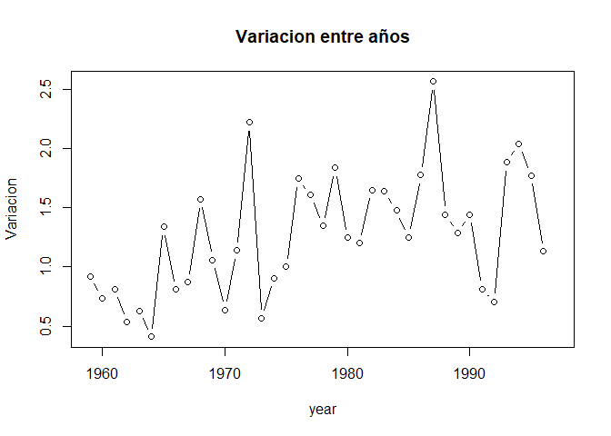

```r
Variacion <-c(diff(co2),NA)
plot(year,Variacion,type = "b",main = "Variacion entre años")
```

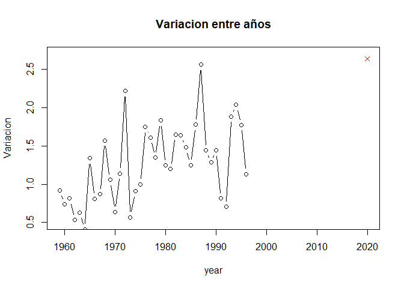

```r
plot(year,Variacion,type = "b",main = "Variacion entre años",xlim =c(1959,2020), ylim=c(0.5,2.7),pch=1)
points(2020,2.64,pch=4,col="red")
```